# Proof of concept: CO2 capture with PCET-based pH swings

For the points of interest, we plot the entire cycle dynamics to attempt to distinguish effects of each variable.

```r
plt.demo.E = function(test.sys, i){
  # Calculate system processes
  test.data = PCET.cycle(pka1 = test.sys$pka1[i], pka2 = test.sys$pka2[i],
                         logA = test.sys$logA[i], Na.A = test.sys$Na[i],
                         acid = test.sys$acid[i])
  # Electrode conditions
  E.test = PCET.electrode(soln.path = test.data, pka1 = test.sys$pka1[i], pka2 = test.sys$pka2[i])
  # Plots
  col = 'gray'
  if(mean(filter(E.test, stage == '1->2')$E) < mean(filter(E.test, stage == '3->4')$E)){
    col = 'lightcoral'
  }
  g = ggplot(E.test) +
    geom_polygon(mapping = aes(x = xA, y = E), fill = col, alpha = 0.5) +
    geom_path(mapping = aes(x = xA, y = E, color = stage), arrow = arrow(length = unit(0.5, "cm")) ) +
    labs(x = '% Reduced Quinone', y = expression('Electrode Potential (V vs E'^0*')'), subtitle = test.sys$label[i]) +
    scale_color_discrete(labels = c('1->2' = 'Oxidative Acidification',
                                    '2->3' = expression('CO'[2]*' Degassing'),
                                    '3->4' = 'Reductive Regeneration',
                                    '4->1' = expression('CO'[2]*' Capture')),
                         name = '')
  return(g)
}

plt.demo.state = function(test.sys, i){
  # Calculate system processes
  test.data = PCET.cycle(pka1 = test.sys$pka1[i], pka2 = test.sys$pka2[i],
                         logA = test.sys$logA[i], Na.A = test.sys$Na[i],
                         acid = test.sys$acid[i])
  # Plots
  g1 = ggplot(test.data) +
    geom_path(mapping = aes(x = xA, y = pH, color = stage), arrow = arrow(length = unit(0.5, "cm"))) +
    # pH plots: include the buffer regimes of the quinones
    geom_hline(yintercept = c(test.sys$pka1[i], test.sys$pka2[i]), color = 'gray', linetype = 2) +
    labs(x = '% Reduced Quinone', y = 'Solution pH', subtitle = test.sys$label[i]) +
    scale_color_discrete(labels = c('1->2' = 'Oxidative Acidification',
                                    '2->3' = expression('CO'[2]*' Degassing'),
                                    '3->4' = 'Reductive Regeneration',
                                    '4->1' = expression('CO'[2]*' Capture')),
                         name = '') +
    guides(color = FALSE)
  g2 = ggplot(test.data) +
    geom_hline(yintercept = c(1, 0.15), linetype = 2, color = 'gray') +
    geom_path(mapping = aes(x = xA, y = p.CO2, color = stage), arrow = arrow(length = unit(0.5, "cm"))) +
    labs(x = '% Reduced Quinone', y = expression('Partial Pressure CO'[2]*' (atm)')) +
    scale_y_log10() +
    scale_color_discrete(labels = c('1->2' = 'Oxidative Acidification',
                                    '2->3' = expression('CO'[2]*' Degassing'),
                                    '3->4' = 'Reductive Regeneration',
                                    '4->1' = expression('CO'[2]*' Capture')),
                         name = '') +
    guides(color = FALSE)

  g3 = ggplot(test.data) +
    geom_path(mapping = aes(x = DIC, y = pH, color = stage), arrow = arrow(length = unit(0.5, "cm"))) +
    geom_hline(yintercept = c(test.sys$pka1[i], test.sys$pka2[i]), color = 'gray', linetype = 2) +
    labs(x = 'Total Inorganic Carbon (M)', y = 'Solution pH') +
    scale_color_discrete(labels = c('1->2' = 'Oxidative Acidification',
                                    '2->3' = expression('CO'[2]*' Degassing'),
                                    '3->4' = 'Reductive Regeneration',
                                    '4->1' = expression('CO'[2]*' Capture')),
                         name = '') +
    guides(color = FALSE)

  g4 = ggplot(test.data) +
    geom_hline(yintercept = c(1, 0.15), linetype = 2, color = 'gray') +
    geom_path(mapping = aes(x = DIC, y = p.CO2, color = stage), arrow = arrow(length = unit(0.5, "cm"))) +
    labs(x = 'Total Inorganic Carbon (M)', y = expression('Partial Pressure CO'[2]*' (atm)')) +
    scale_y_log10() +
    scale_color_discrete(labels = c('1->2' = 'Oxidative Acidification',
                                    '2->3' = expression('CO'[2]*' Degassing'),
                                    '3->4' = 'Reductive Regeneration',
                                    '4->1' = expression('CO'[2]*' Capture')),
                         name = '')

  g = (g1 + g3) / (g2 + g4)
  return(g)
}
```

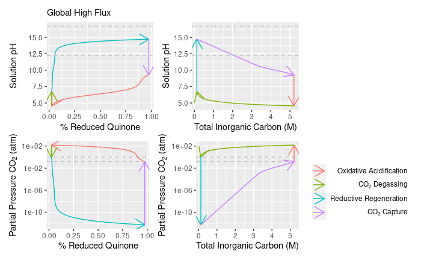

```r
plt.demo.state(test.sys = test.sys, i = 1)
```

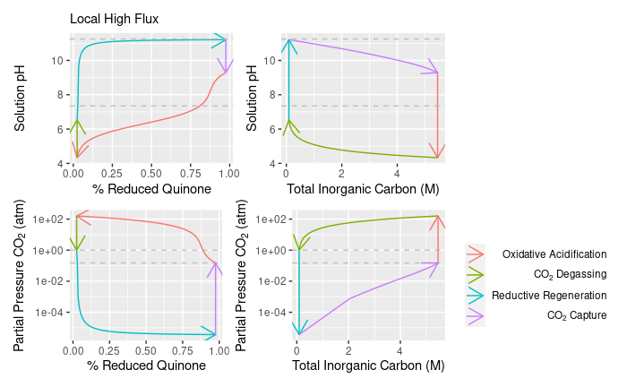

```r
plt.demo.state(test.sys = test.sys, i = 2)
```

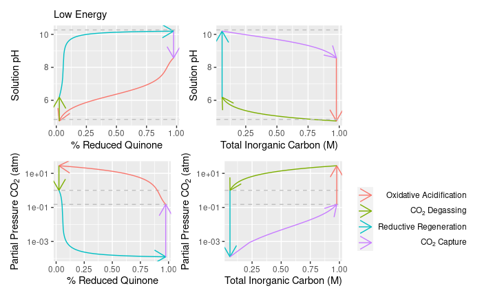

```r
plt.demo.state(test.sys = test.sys, i = 3)
```

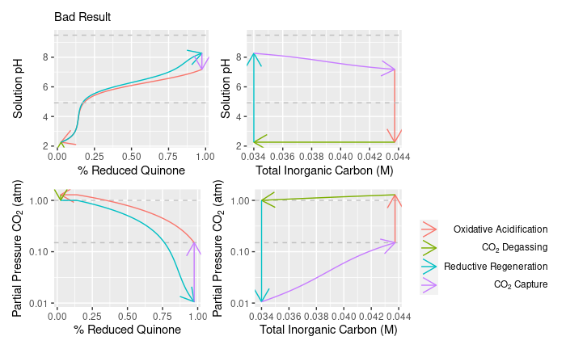

```r
plt.demo.state(test.sys = test.sys, i = 4)
```

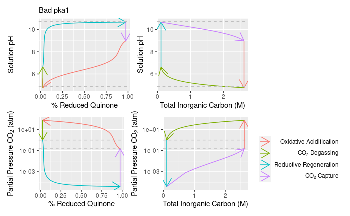

```r
plt.demo.state(test.sys = test.sys, i = 5)
```

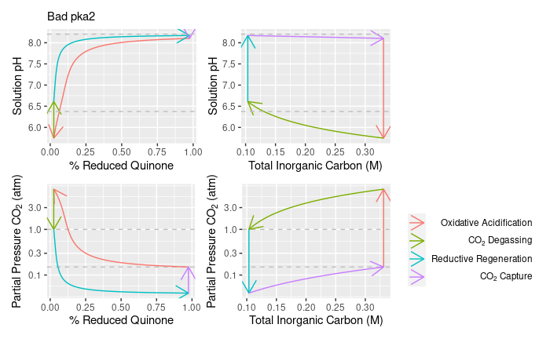

```r
plt.demo.state(test.sys = test.sys, i = 6)
```

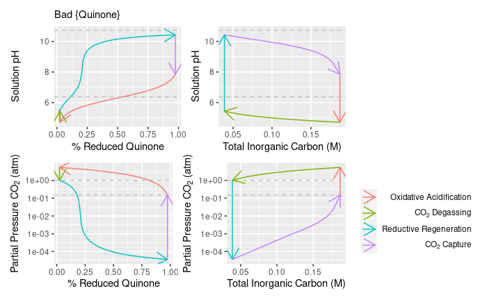

```r
plt.demo.state(test.sys = test.sys, i = 7)
```

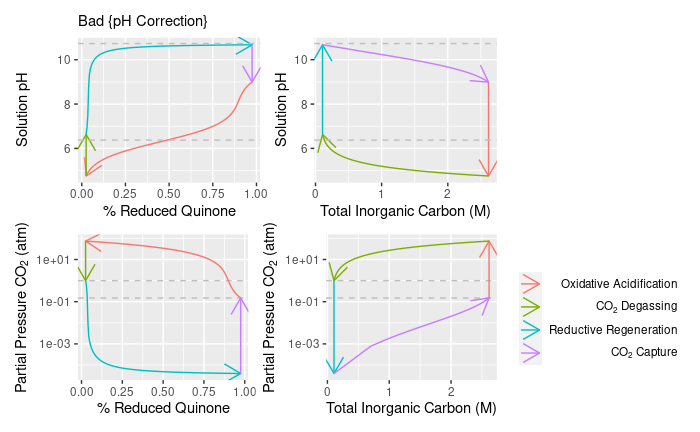

```r
plt.demo.state(test.sys = test.sys, i = 8)
```

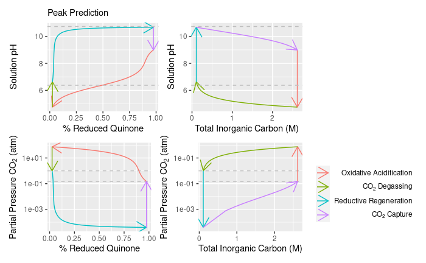

```r
plt.demo.state(test.sys = test.sys, i = 9)
```

Important cycles to export for formal plotting:

```r
stage.rename = function(test.data){
  test.data$stage[test.data$stage == '1->2'] = 'Oxidative Acidification'
  test.data$stage[test.data$stage == '2->3'] = 'CO2 Degassing'
  test.data$stage[test.data$stage == '3->4'] = 'Reductive Regeneration'
  test.data$stage[test.data$stage == '4->1'] = 'CO2 Capture'
  return(test.data)
}
# High global flux
i = 1;
test.data = PCET.cycle(pka1 = test.sys$pka1[i], pka2 = test.sys$pka2[i],
                       logA = test.sys$logA[i], Na.A = test.sys$Na[i],
                       acid = test.sys$acid[i])
E.test = PCET.electrode(soln.path = test.data, pka1 = test.sys$pka1[i], pka2 = test.sys$pka2[i])
test.data = stage.rename(test.data)
E.test = stage.rename(E.test)
# Store
write.csv(test.data, 'CycleProcess_HighFlux.csv')
write.csv(E.test, 'CycleVoltage_HighFlux.csv')

# Peak prediction
i = 9
test.data = PCET.cycle(pka1 = test.sys$pka1[i], pka2 = test.sys$pka2[i],
                       logA = test.sys$logA[i], Na.A = test.sys$Na[i],
                       acid = test.sys$acid[i])
E.test = PCET.electrode(soln.path = test.data, pka1 = test.sys$pka1[i], pka2 = test.sys$pka2[i])
test.data = stage.rename(test.data)
E.test = stage.rename(E.test)
# Store
write.csv(test.data, 'CycleProcess_PeakPredict.csv')
write.csv(E.test, 'CycleVoltage_PeakPredict.csv')


# Bad result
i = 4
test.data = PCET.cycle(pka1 = test.sys$pka1[i], pka2 = test.sys$pka2[i],
                       logA = test.sys$logA[i], Na.A = test.sys$Na[i],
                       acid = test.sys$acid[i])
E.test = PCET.electrode(soln.path = test.data, pka1 = test.sys$pka1[i], pka2 = test.sys$pka2[i])
test.data = stage.rename(test.data)
E.test = stage.rename(E.test)
# Store
write.csv(test.data, 'CycleProcess_PoorPredict.csv')
write.csv(E.test, 'CycleVoltage_PoorPredict.csv')

# Export points of interest
write.csv(test.sys[c(1, 4, 9), !names(test.sys) %in% 'dist'], 'Cycle_PointsOfInterest.csv')
```

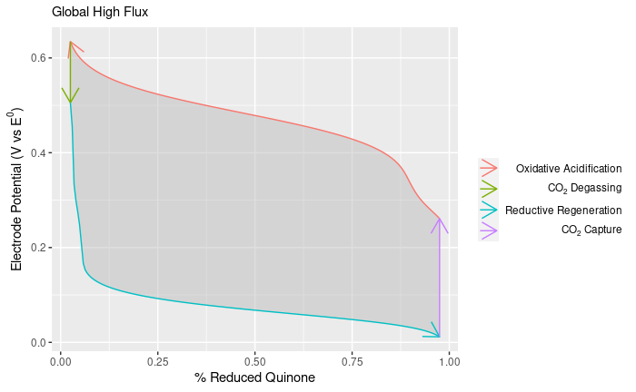

```r
plt.demo.E(test.sys = test.sys, i = 1)
```

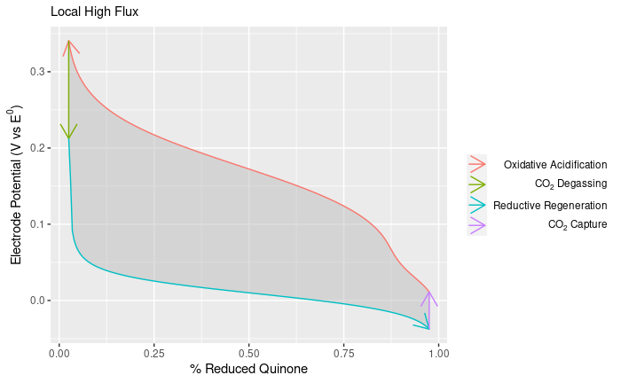

```r
plt.demo.E(test.sys = test.sys, i = 2)
```

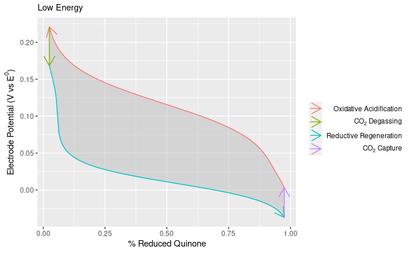

```r
plt.demo.E(test.sys = test.sys, i = 3)
```

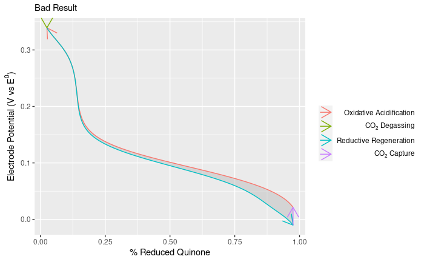

```r
plt.demo.E(test.sys = test.sys, i = 4)
```

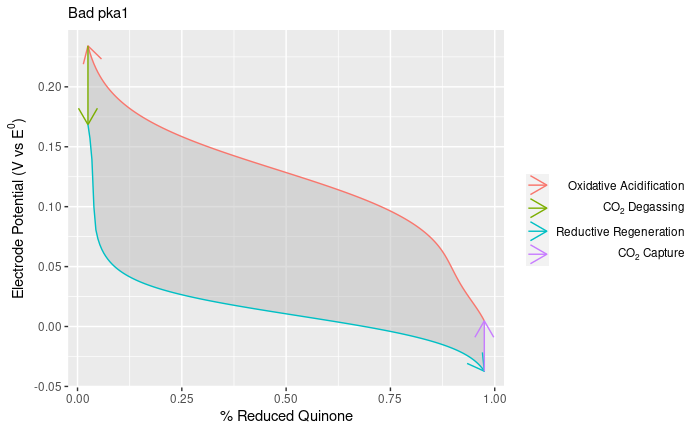

```r
plt.demo.E(test.sys = test.sys, i = 5)
```

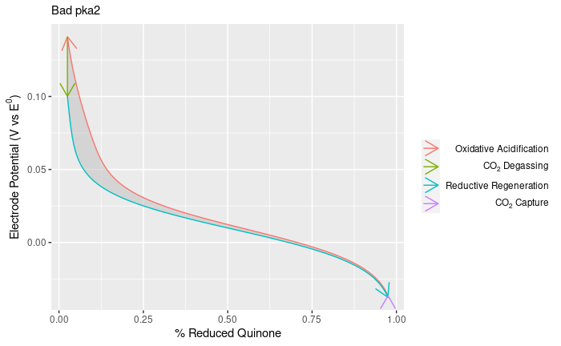

```r
plt.demo.E(test.sys = test.sys, i = 6)
```

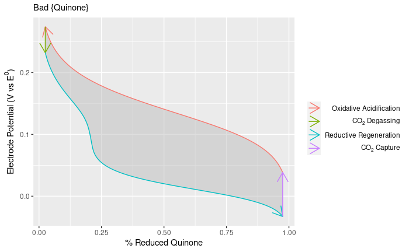

```r
plt.demo.E(test.sys = test.sys, i = 7)
```

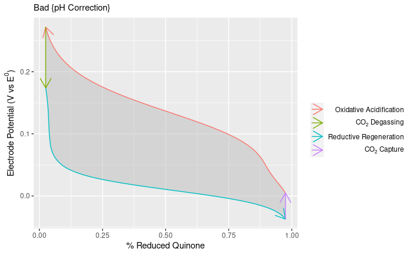

```r
plt.demo.E(test.sys = test.sys, i = 8)
```

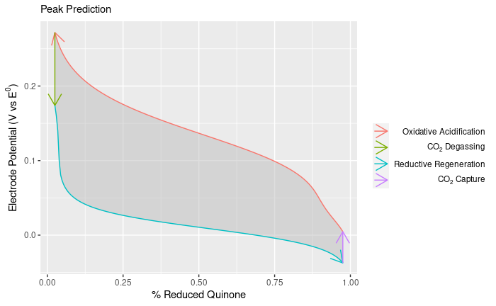

```r
plt.demo.E(test.sys = test.sys, i = 9)
```

Electrode potentials track with the solution pH due to the pH dependence of the Nernst potential.

# Compare to known data

A small set of quinone pKas was used to constrain the search space. This same dataset can be assessed for the likelihood that any compound will be viable given only the pKa values.

```r
quinone.data$p.accept = NaN
lower = 0.25; upper = 0.75
MCsamp = 600
logA.rng = c(-2, 0.5); Na.A.rng = c(-7, 0.7)
F.cutof = reg.full$min.flux
E.cutof = reg.full$max.ener

for(i in 1:nrow(quinone.data)){
  # pKas
  fill.frame = data.frame(pka1 = quinone.data$Pka.1[i],
                          pka2 = quinone.data$Pka.2[i],
                          logA = runif(n = MCsamp, min = logA.rng[1], max = logA.rng[2]),
                          Na.A = runif(n = MCsamp, min = Na.A.rng[1], max = Na.A.rng[2]))
  set.flux = sample(1:length(mod.flux.a), length(mod.flux.a))
  set.ener = sample(1:length(mod.ener.a), length(mod.ener.a))
  p = rep(NA, 2*length(mod.flux.a))
  for(j in 1:length(set.flux)){
    res.flux = predict(object = mod.flux.a[[set.flux[j]]], newdata = fill.frame, type = 'UK')
    res.ener = predict(object = mod.ener.a[[set.ener[j]]], newdata = fill.frame, type = 'UK')
    p.accept = (1 - pnorm(q = 0, mean = res.flux$mean - F.cutof, sd = res.flux$sd)) *
      pnorm(q = 0, mean = res.ener$mean - E.cutof, sd = res.ener$sd)
    p[j] = mean(p.accept)
    res.flux = predict(object = mod.flux.b[[set.flux[j]]], newdata = fill.frame, type = 'UK')
    res.ener = predict(object = mod.ener.b[[set.ener[j]]], newdata = fill.frame, type = 'UK')
    p.accept = (1 - pnorm(q = 0, mean = res.flux$mean - F.cutof, sd = res.flux$sd)) *
      pnorm(q = 0, mean = res.ener$mean - E.cutof, sd = res.ener$sd)
    p[j+length(mod.flux.a)] = mean(p.accept)
  }
  quinone.data$p.accept[i] = mean(p)
}

# Show most promising candidates in order from most to least likely to work
quinone.data[order(quinone.data$p.accept, decreasing = TRUE), !(names(quinone.data) %in% c('QuinoneCode', 'E0.1', 'E0.2'))]
```

|  | R2 | R3 | R5 | R6 | Pka.2 | Pka.1 | p.accept |
| --- | --- | --- | --- | --- | --- | --- | --- |
| 28 | N(CH3)2 | N(CH3)2 | H | H | 11.11 | 9.43 | 0.852482261 |
| 74 | OH | H | H | OH | 10.68 | 8.43 | 0.841471687 |
| 53 | OCH2CH3 | H | OCH2CH3 | H | 11.07 | 9.98 | 0.838267140 |
| 58 | SiH3 | H | SiH3 | H | 9.20 | 7.78 | 0.834450750 |
| 27 | OCH3 | OCH3 | H | H | 10.97 | 7.77 | 0.832471750 |
| 69 | C(CH3)3 | H | H | C(CH3)3 | 13.18 | 10.49 | 0.832210895 |
| 21 | SO3- | H | H | H | 11.17 | 9.25 | 0.831312827 |
| 1 | H | H | H | H | 11.40 | 9.85 | 0.830993716 |
| 52 | OH | H | OH | H | 10.85 | 9.76 | 0.830730951 |
| 63 | COOH | H | COOH | H | 10.43 | 8.22 | 0.829632597 |

[output cut: 117 more lines]

```r
p.cutof = max(quinone.data$p.accept)*0.7
range(filter(quinone.data, p.accept > p.cutof)$Pka.1)
```

```
[1]  1.13 13.41
```

```r
range(filter(quinone.data, p.accept > p.cutof)$Pka.2)
```

```
[1]  7.98 15.34
```

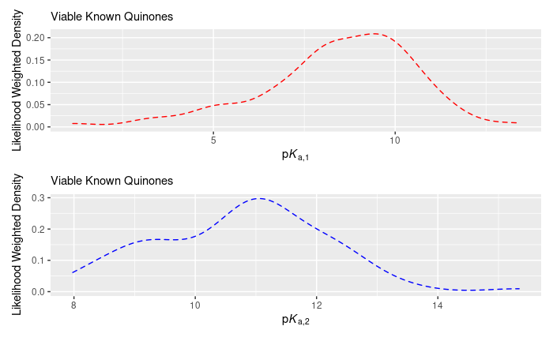

```r
# Plot densities weighted by the acceptance probabilities
g1 = ggplot() +
  # Data
  # geom_density(data = quinone.data, mapping = aes(x = Pka.1, weight = p.accept), color = 'red') +
  geom_density(data = filter(quinone.data, p.accept > p.cutof),
               mapping = aes(x = Pka.1), color = 'red', linetype = 2) +
  # Optimal ranges
  # geom_vline(xintercept = pka1.rng.st, color = 'darkred', linetype = 'dotted', alpha = 0.5) +
  labs(x = expression('p'*italic(K)['a,1']), y = 'Likelihood Weighted Density', subtitle = 'Viable Known Quinones',
       color = '')

g2 = ggplot() +
  # Data
  # geom_density(data = quinone.data, mapping = aes(x = Pka.2, weight = p.accept), color = 'blue') +
  geom_density(data = filter(quinone.data, p.accept > p.cutof),
               mapping = aes(x = Pka.2), color = 'blue', linetype = 2) +
  # Optimal ranges
  # geom_vline(xintercept = pka2.rng.st, color = 'darkblue', linetype = 'dotted', alpha = 0.5) +
  labs(x = expression('p'*italic(K)['a,2']), y = 'Likelihood Weighted Density', subtitle = 'Viable Known Quinones',
       color = '')
g1 / g2
```

```r
rm(g1, g2)
```

More than half of the candidates have at least a 50% likelihood of performing well, indicating that there are a number of known candidates that may work. The distribution of known quinones (weighted by their probabilities) shows that quinones with pKa near the single variable marginal peaks are important to investigate in future studies.

Breakdown into function groups, organized by their electronic effect (donating/withdrawing)

```r
groups = unique(c(quinone.data$R2, quinone.data$R3, quinone.data$R5, quinone.data$R6))
# Not concerned with the hydrogen case
groups = groups[-c(groups %in% 'H')]
groups
```

```
 [1] "C6H5"    "CH3"     "C(CH3)3" "OCH3"    "N(CH3)2" "NH2"     "CH2CH3"  "OH"      "OCH2CH3" "F"
[11] "Cl"      "Br"      "SH"      "SiH3"    "CHO"     "COOCH3"  "CF3"     "CN"      "COOH"    "SO3-"
[21] "NO2"     "COCH3"
```

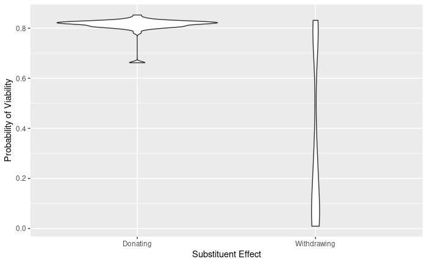

```r
# Classifying the groups according to donoating/withdrawing and relative strength (using the standard ladder)
type = c('Donating', 'Donating', 'Donating', 'Donating', 'Donating', 'Donating', 'Donating', 'Donating',
                    'Donating', 'Withdrawing', 'Withdrawing', 'Withdrawing', '?', '?', 'Withdrawing', 'Withdrawing',
                    'Withdrawing', 'Withdrawing', 'Withdrawing', 'Withdrawing', 'Withdrawing', 'Withdrawing')
str = c(2, 3, 3, 6, 9, 8, 3, 7, 6, -1, -1, -1, NA, NA, -2, -4, -7, -8, -5, -8, -12, -3)

# Find average probability if any substitutions are that functional group
group.dist = data.frame()
for(i in 1:length(groups)){
  subst = groups[i]
  # Probability of being viable
  p.viable = c(filter(quinone.data, R2 == subst)$p.accept, filter(quinone.data, R3 == subst)$p.accept,
               filter(quinone.data, R5 == subst)$p.accept, filter(quinone.data, R6 == subst)$p.accept)
  # Standard reduction potentials
  e1 = c(filter(quinone.data, R2 == subst)$E0.1, filter(quinone.data, R3 == subst)$E0.1,
         filter(quinone.data, R5 == subst)$E0.1, filter(quinone.data, R6 == subst)$E0.1)
  e2 = c(filter(quinone.data, R2 == subst)$E0.2, filter(quinone.data, R3 == subst)$E0.2,
         filter(quinone.data, R5 == subst)$E0.2, filter(quinone.data, R6 == subst)$E0.2)

  group.dist = rbind(group.dist,
                     data.frame(group = subst, probs = p.viable,
                                E01 = e1, E02 = e2,
                                type = type[i], str = str[i]) )
}
# group.dist
ggplot(filter(group.dist, is.na(str) == FALSE)) +
  geom_violin(mapping = aes(x = type, y = probs)) +
  labs(x = 'Substituent Effect', y = 'Probability of Viability')
```

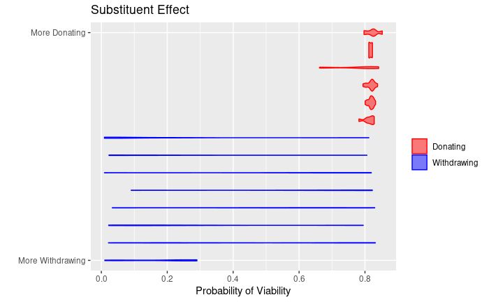

```r
ggplot(filter(group.dist, is.na(str) == FALSE)) +
  geom_violin(mapping = aes(x = as.factor(str), y = probs, fill = type, color = type), alpha = 0.5, weight = 20) +
  labs(title = 'Substituent Effect', y = 'Probability of Viability', x = '', fill = '', color = '') +
  scale_x_discrete(breaks = c(-12, 9),
                   labels = c('More Withdrawing', 'More Donating')) +
  scale_color_manual(values = c('red', 'blue')) +
  scale_fill_manual(values = c('red', 'blue')) +
  coord_flip()
```

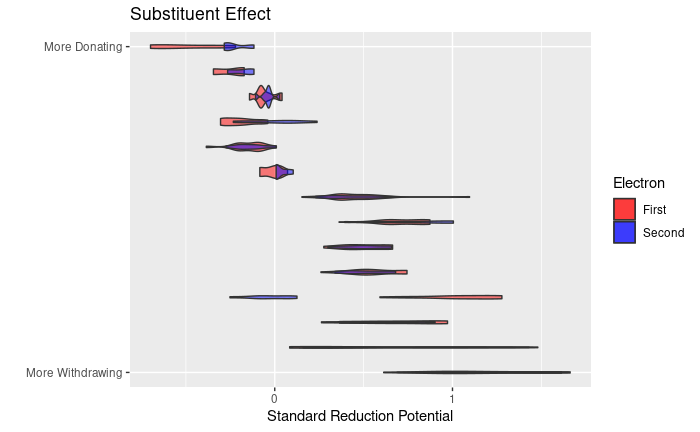

```r
ggplot(filter(group.dist, is.na(str) == FALSE)) +
  geom_violin(mapping = aes(x = as.factor(str), y = E01, fill = 'e1'), alpha = 0.5) +
  geom_violin(mapping = aes(x = as.factor(str), y = E02, fill = 'e2'), alpha = 0.5) +
  labs(title = 'Substituent Effect', y = 'Standard Reduction Potential', x = '') +
  scale_x_discrete(breaks = c(-12, 9),
                   labels = c('More Withdrawing', 'More Donating')) +
  scale_fill_manual(name = 'Electron',
                     labels = c('e1' = 'First', 'e2' = 'Second'),
                     values = c('e1' = 'red', 'e2' = 'blue')) +
  coord_flip()
```

Electron donating groups increase the probability of viability substantially, but withdrawing groups are not necessarily a detriment given their wide distribution.

```r
# Store substituent effect calculation results
write.csv(quinone.data, 'QuinoneProbs.csv')
write.csv(group.dist, 'SubstEffect.csv')
```